# Binary Logistic Regression

Using binary regression to test the feasibility of using plant characteristics to classify palmetto species.

Nicole Schmidt true  
03-10-2021

```r
knitr::opts_chunk$set(echo = TRUE, warning = FALSE, messages = FALSE)

# Attach packages and read in data

library(tidyverse)
library(janitor)
library(here)
library(broom)
library(GGally)
library(jtools)
library(dplyr)
library(kableExtra)


# Read in data and tidy; rename plant species, select variables.

palmetto <- read_csv("palmetto.csv") %>%
  select(year, plant, species, height, length, width, green_lvs) %>%
 mutate(species = case_when(species %in% c("1") ~ "Serenoa repens",
                            species %in% c("2") ~ "Sabal etonia"))

palmetto$species <- as.factor(palmetto$species)
```

#### Introduction

The palmetto data set contains growth and survival data for two dominant palmetto species, *Serenoa repens* and *Sabal etonia*, across multiple habitats, years, and experimental treatments. Data was recorded at the Archbold Biological Station located in Florida. This project highlights differences in height, canopy length, canopy width, and green leaves for the two species. A binary logistic regression model is used to see the odds of predicting correctly or incorrectly if a plant species is either the *Sabal etonia* or *Serenoa repens* based on plant height, canopy length, canopy width, and green leaves count.

#### Data exploration

[figure not shown]

```r
# Finalize Graphs

ggplot(data = palmetto, aes(x = height, y = green_lvs))+
  geom_jitter(aes(color=species))+
  facet_wrap(~species)+
  labs( x = "Height(cm)", y = "Green leaves count",
        title = "Green leaves count and height comparison between Sabal etonia and Serenoa repens",
        subtitle = ("1981 - 2017"),
        fill = "Species",
        caption = "Figure 1. Height(cm) and canopy width (cm) for Sabal Etonia and Serenoa repens")+
  theme_bw()+
  scale_color_manual(values = c("green", "dark green"))
```

- *Serenoa repens* has a higher green leaf count than *Sabal etonia*
- *Serenoa repens* has more individuals that are greater in height than *Sabal etonia*

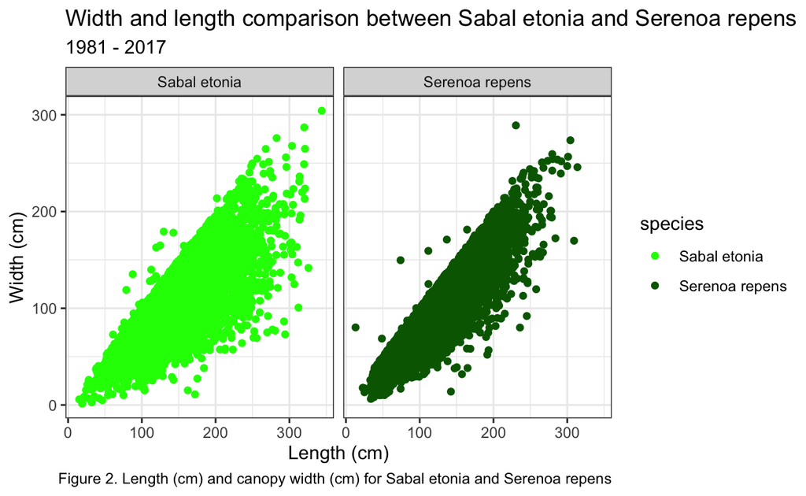

```r
# Second Graph Height and Width

ggplot(data = palmetto, aes(x = length, y = width))+
  geom_jitter(aes(color=species))+
  facet_wrap(~species)+
    labs( x = "Length (cm)", y = "Width (cm)",
        title = "Width and length comparison between Sabal etonia and Serenoa repens",
        subtitle = ("1981 - 2017"),
        fill = "Species",
        caption = "Figure 2. Length (cm) and canopy width (cm) for Sabal etonia and Serenoa repens")+
  theme_bw()+
    scale_color_manual(values = c("green", "dark green"))
```

- Both *Sabal etonia* and *Serenoa repens* have a positive correlation with length and width. As the length of plants grow so do the width of both plants

#### Binary Logistic Regression

The next step in the analysis is to utilize a binary logistic regression model. The binary logistic regression model will be used to see the probability of predicting correctly if a plant species is either the *Sabal etonia* or *Serenoa repens* based on plant height, canopy length, canopy width, and green leaves count.

```r
palmetto_blr <- glm(species ~ length +
                              width + green_lvs + height,
                            data = palmetto,
                            family = "binomial")


#checking levels(palmetto$species):
#0 is Serenoa
#1 is Sabel
# interpret as the probability of serenoa repens

#when the model is above 50% probability it is serenoa classification
#when the model is below 50% it is likely sabal.
```

**Table 1:** Binomial Logistic Regression Outcomes for *Serenoa repens* and *Sabal etonia*

```r
# Table

palmetto <- palmetto_blr %>%
  broom::tidy() %>%
  select(estimate, std.error, p.value) %>%
  mutate_if(is.numeric,funs(as.character(signif(.,3))))

rownames(palmetto) <- c("Intercept",
                        "Length (cm)",
                        "Width (cm)",
                        "Green Leaves (n)",
                        "Height (cm)")

kableExtra::kable(palmetto,
                  col.names= c("Coefficient",
                            "Standard Error",
                            "p-value")) %>%
  kableExtra::kable_styling(bootstrap_options = "striped",
                            full_width = F,
                            position ="center") %>%
  kableExtra::add_header_above(bold = TRUE,
                               line = TRUE,
                               c("Binomial Logistic Regression for _Serenoa repens_, and _Sabal etonia_" = 4))
```

| Binomial Logistic Regression for *Serenoa repens*, and *Sabal etonia* | Binomial Logistic Regression for *Serenoa repens*, and *Sabal etonia* Coefficient | Binomial Logistic Regression for *Serenoa repens*, and *Sabal etonia* Standard Error | Binomial Logistic Regression for *Serenoa repens*, and *Sabal etonia* p-value |
| --- | --- | --- | --- |
| Intercept | -3.23 | 0.142 | 3.42e-114 |
| Length (cm) | -0.0458 | 0.00187 | 3.73e-133 |
| Width (cm) | -0.0394 | 0.0021 | 1.05e-78 |
| Green Leaves (n) | 1.91 | 0.0389 | 0 |
| Height (cm) | 0.0292 | 0.00231 | 8.69e-37 |

#### Summary

- As the canopy length of the plant increases, the odds of the plant being *Serenoa repens* decreases.
- As the width of the plant increases, the odds of the plant being *Serenoa repens* decreases.
- As the green leave count increases the odds of the plant being a *Serenoa repens* increases.
- As the height of the plant increases, the odds of the plant being a *Serenoa repens* increases.

**Table 2.** Incidents of correct and incorrect predictions of palmetto species based on the binary logistic model of predictor variables

```r
#model fitting

blr_fitted <- palmetto_blr %>%
  broom::augment(type.predict = "response") %>%
  mutate(predicted = ifelse(.fitted >= .5, "Serenoa repens", "Sabal etonia")) %>%
  mutate(correct = ifelse(predicted == species, "predicted_correctly", "predicted_incorrectly"))

palmetto_table <- blr_fitted %>%
  count(species, correct) %>%
pivot_wider(names_from = correct, values_from = n) %>%
mutate(total = rowSums(across(where(is.numeric)))) %>%
mutate(percent = (predicted_correctly / total)* 100) %>%
 mutate_if(is.numeric,funs(as.character(signif(.,3))))


kableExtra::kable(palmetto_table,
                  col.names= c("Species", "Correct Prediction",
                               "Incorrect Prediction", "Total", "% Correct")) %>%
    kableExtra::kable_styling(bootstrap_options = "striped",
                            full_width = F,
                            position ="center") %>%
  kableExtra::add_header_above(bold = TRUE,
                               line = TRUE,
                               c("Percent species predicted correctly by binary logistic regression model" = 5))
```

| Percent species predicted correctly by binary logistic regression model Species | Percent species predicted correctly by binary logistic regression model Correct Prediction | Percent species predicted correctly by binary logistic regression model Incorrect Prediction | Percent species predicted correctly by binary logistic regression model Total | Percent species predicted correctly by binary logistic regression model % Correct |
| --- | --- | --- | --- | --- |
| Sabal etonia | 5700 | 454 | 6160 | 92.6 |
| Serenoa repens | 5550 | 564 | 6110 | 90.8 |

#### Summary

Based on the binary logistic regression model, the odds of predicting the *Sabal etonia* based on the plant characteristics of height, canopy length, canopy width, and green leaves count is 92.6%, and the odds of predicting the *Serenoa repens* is 90.8%.

### Data Source

Abrahamson, W.G. 2019. Survival, growth and biomass estimates of two dominant palmetto species of south-central Florida from 1981 - 2017, ongoing at 5-year intervals ver 1. Environmental Data Initiative. https://doi.org/10.6073/pasta/f2f96ec76fbbd4b9db431c79a770c4d5